# 데이터사이언스 입문 프로젝트 중간 보고서

2019-04-20

## 문제 제기

최근 각종 첨단 기술을 접목한 금융 산업이 화두로 떠오르면서 간편 결제 시장 또한 빠른 속도로 성장하고 있다. 그러나 간편 결제 이용자는 대부분 2-30대의 젊은층에 한정되어 있고 **모바일 환경에 익숙하지 않은 중,노년층은 간편 결제 시장에서 소외되고 있다.** 아래 자료를 보면 2030 세대에 비해 40대 이상의 중, 노년층, 특히 5060 세대의 간편결제 이용률이 현저하게 떨어짐을 알 수 있다.

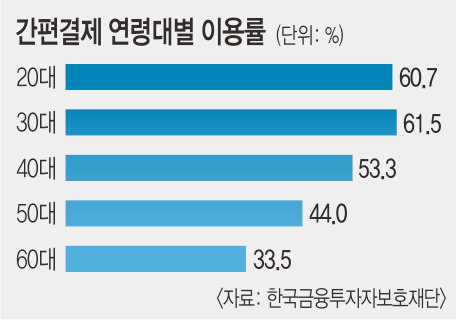

그 결과 대부분 **간편 결제 서비스의 혜택들은 주 사용자인 2030 세대에 맞추어져 있고, 중, 노년층의 소외 현상은 더욱 심화되고 있다.**

그러나 최근의 5060세대는 모바일 어플을 통해 경조사를 챙기거나 모바일을 이용한 더치페이를 활용하는 등 모바일, 온라인을 이용한 금융 서비스에 점차 익숙해지고 있다. 또한 이들은 **안정적인 경제력을 바탕으로 간편 결제 시장의 ‘큰 손’이 될 가능성이 높은 세대이다.** 뿐만 아니라 이들은 과거의 베이비붐 세대로서 우리나라에서 차지하는 인구 비율 역시 매우 높다. 따라서 이들은 2030 세대 못지 않은 거대한 잠재 소비자로서 자리하고 있다. **즉, 5060 세대는 간편 결제 시장의 블루 오션으로서, 간편 결제 업체들이 반드시 공략해야 할 타겟 소비자층이다.**

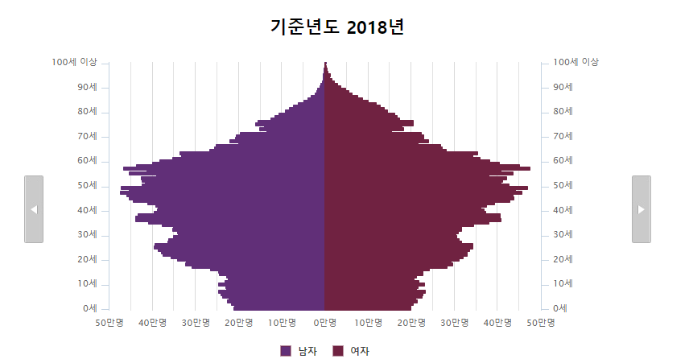

그렇다면 5060 세대를 효과적으로 공략하기 위해서는 어떻게 해야할까? 많은 설문 조사에 따르면, **금융 회사들이 제공하는 ‘경제적 혜택’은 모바일, 온라인 결제에 익숙하지 않은 5060 세대가 모바일, 온라인 결제를 이용하게 된 가장 큰 이유였다.**

따라서 우리 조는 5060 세대에 대한 분석을 바탕으로 **이들에게 최적화된 할인혜택, 서비스 등 경제적 유인을 제공하여 5060 세대를 간편 결제 시장으로 유입시키고자 한다. 또한 5060 세대가 간편 결제 시스템에 익숙해질 수 있도록 이들에게 알맞은 광고, 홍보 방안 또한 제시하고자 한다.**

## 조사 주제

**5060 세대의 간편 결제 이용률 증가를 위한 방안 제안**

## 활용 데이터와 분석 도구

엠브레인 패널들은 10대에서 60대까지 다양한 연령 분포를 보이며, 전국 각지에 다양하게 거주하고 있다.

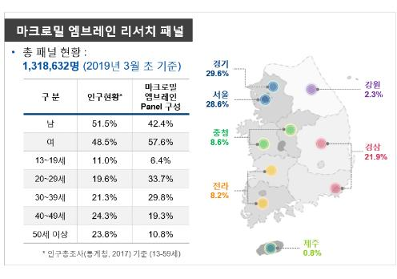

**엠브레인 패널들의 설문 조사 데이터, 결제 데이터, 앱 사용 데이터를 R을 이용하여 분석한다.** 우리가 활용하고자 하는 데이터의 구체적인 내용은 다음과 같다.

- 간편결제사 정보: 회사이름, 연계 금융사
- 소비자 기본 정보: 성별, 연령, 거주지역, 결혼상태, 학력, 직업
- 소비자 설문 정보
  - 가구
    - 동거자수
    - 연소득(가족전체)
    - 주택형태, 주택보유형태(자산예측목적)
  - 금융
    - 지난 1개월 간 이용한 경험이 있는 지불/결제 방식(온라인/모바일, 오프라인)
    - 지난 1년간 경험한 금융/재테크 관련 활동(보험, 예적금 및 투자, 대출, 기타(기부))
  - Health
  - Shopping
  - Digital Life
  - Hobby/Leisure
  - Media
- 가맹점 정보
  - 업종, 브랜드
  - 위치(위경도)
  - 결제날짜(연월일시간)
  - 거래금액
- 패널들의 어플리케이션 이용 정보
  - 이용 시간, 이용 어플리케이션 종류 등

## 현재까지 진행 상황

### 간편 결제 시장 분석

2017년 **국내 간편 결제 서비스 거래액은 40조원으로 2016년(11조7810억원)보다 3배 이상 성장하였으며, 특히 온라인 간편 결제 시장의 성장이 두드러짐.** 현재 간편 결제 시장은 **상위 플레이어 4사(삼성페이, 네이버페이, 카카오페이, 페이코)의 영향력이 매우 큼.**

그러나 **아직까지 국내 지급 결제 시장에서 선호도는 신용카드가 매우 높은 상태임.** 일평균 간편결제 금액은 전체 신용카드 거래액의 3% 수준에 불과하며, 오프라인 모바일 결제 이용자의 월평균 이용건수 및 금액은 각각 5.4건, 7만원 수준에 불과함.

현재 다양한 간편결제 업자들이 시장에 진출하고 있으나, **우수한 인프라와 범용성, 편리성을 확보한 업체들 중심으로 시장이 단순화될 것이라고 예상됨.** 따라서 **경쟁에서 살아남기 위해서는 신용카드보다 뛰어난 편리성, 다양한 혜택 등을 제공하여 소비자를 유치해야 함.**

현재 국내에는 다양한 간편 결제 업체들이 존재하고 있으며, 업체 별로 간편 결제 구동 방식(자기장 방식, NFC 방식 등), 온/오프라인 지원 여부, 가맹점의 종류 등이 모두 다르기 때문에 **각 업체별 특징과 장단점이 뚜렷하게 나타남.**

현재 **온라인 시장에서는 네이버페이, 카카오페이가 강세를 이루고 있으며, 오프라인 시장에서는 삼성페이가 압도적인 이용률과 가맹점 수를 보유함.** 그러나 다른 간편 결제 업체들도 가맹점 확대, 혜택 확대 등을 통해 시장 점유율을 증가시키고자 하고 있음.

### EDA

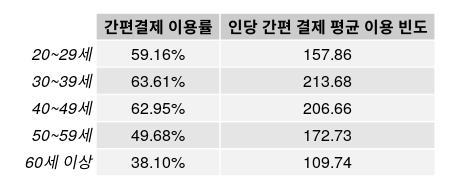

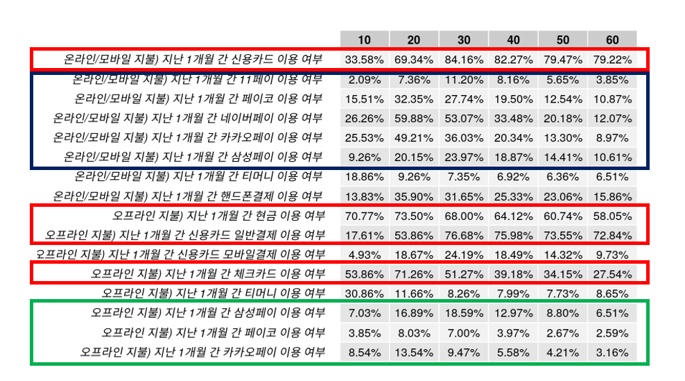

- **실제 데이터에서 5060 세대가 간편 결제를 잘 이용하지 않는다는 사실을 다시 한 번 확인하였음.**
- 아직 활성화에 어려움을 겪고 있는 오프라인 간편 결제 시장 뿐만 아니라 **상대적으로 활성화되어 있는 온라인 간편 결제 시장에서도 5060 세대가 소외되어 있음.**

### 웹앱 구축

- https://shiny.pjshwa.me/
  - 데이터 도표를 쉽게 분석할 수 있도록 구축함. 이후 추가적인 서비스를 구축할 예정.

### GitHub repository

- https://github.com/desaip2468/deguri

## 앞으로의 일정

**5060 세대를 간편 결제 이용자 (Heavy user / Light user)와 미 이용자로 분류**한다. 이 때 **‘Clustering’(군집분석) 기법을 사용하여 각 집단 별 특성 차이를 살펴본다.** 구체적으로 비계층적 군집 분석인 ‘K-mean clustering’방법을 사용하고자 한다.

Heavy user와 Light user를 나누는 기준은 ‘결제 금액의 합’으로 지정한다. 간편 결제 회사의 입장에서 소액을 자주 결제하는 사람보다는 적은 빈도라도 많은 금액을 결제하는 사람이 핵심 고객이기 때문이다.

**각 집단의 특성을 비교하기 위한 설명 변수로는 자주 이용하는 가맹점의 종류와 위치, 결제 빈도, 자주 이용하는 간편 결제 회사, 자주 이용하는 어플리케이션 종류 등이 있다.** 가맹점 종류, 어플리케이션 종류 등은 특성 별로 그룹화한다. 또한 추후 논의를 통해 추가적인 설명 변수를 설정하고자 한다.

**또한, 간편 결제 시장 분석 결과를 바탕으로 간편 결제 회사들을 온/오프라인, 이용 방법 등에 따라 분류하고 각 회사별로 적합한 마케팅 방안을 도출한다.**

## 기대 효과

5060 세대의 간편 결제 이용 패턴을 분석하여 **고령화 시대의 핵심 고객인 5060 세대를 공략할 수 있는 방안을 제시한다.** 특히 **5060 세대를 세부 집단으로 분류하여 분석함으로써 보다 정교한 분석과 타겟팅 전략을 도출할 수 있다.**

이를 통해 **간편 결제 회사**는 기존 2030 세대 중심의 마케팅에서 벗어나 **새로운 타겟 집단을 설정하고, 경쟁적인 간편 결제 시장에서의 활로를 모색할 수 있다.** 특히 뚜렷한 강자가 존재하는 2030 세대 대상 간편 결제 시장과 달리 **5060 세대 대상 간편 결제 시장에서는 강자와 약자가 뚜렷이 구분되어 있지 않은 상태이다.** 따라서 **현재 부진한 성적을 거두고 있는 간편 결제 업체라면, 5060 세대를 공략하는 것이 효과적일 수 있다.**

**5060 세대는 기존의 소외 현상에서 벗어나 간편 결제 서비스를 통한 편리하고 맞춤화된 금융 생활을 누릴 수 있으며**, 삶의 질 또한 향상시킬 수 있다.